# Lab 3 — Correlation, Regression & Residuals

Quantitative Reasoning · LAB 413

Instructor: Subin Na

September 17, 2025

> **How to use this document.** Run the code along with me. Comments start with `#`. Each section mirrors the live lab; code chunks show the command and its output together.

**Today’s plan**

1. Clean environment + setup
2. Import & understand School data
3. Make a smaller data frame (base vs tidyverse)
4. Descriptive stats (mean, sd)
5. Correlation
6. Linear regression
7. Residuals (what they are & how to plot)
8. Quick practice

# 1 Clean Environment + Setup

Always follow these steps when you open RStudio:

1. Install packages (only once on your computer)
2. Load packages (every new session)
3. Set your working directory
4. Import your dataset

```r
rm(list = ls())   # clean previous objects so we start fresh

# Load packages (every new R session)
library(tidyverse)   # collection of core data science packages (ggplot2, readr, ...)
library(dplyr)       # data manipulation (select, filter, mutate, summarize)
library(ggplot2)     # data visualization (plots, graphs)
library(conflicted)  # handles conflicts when two packages share function names

# If function names conflict (e.g., filter from dplyr vs stats), prefer dplyr's:
conflicts_prefer(dplyr::filter)
```

> In the live session we set the working directory with `setwd(...)`. In this document the data file `SchoolData.csv` sits next to the `.Rmd`, so no `setwd()` is needed.

# 2 Import & Understand School Data

Data source: School Discipline & Attendance (Philadelphia).

```r
schooldata <- read.csv("SchoolData.csv")

# In RStudio you would run View(schooldata); here we preview the first rows.
knitr::kable(head(schooldata))
```

| year_academic | id_school | name_school | sector | category | group | oss_denom | oss_0_numer | oss_0_pct | oss_1_numer | oss_1_pct | oss_2_numer | oss_2_pct | oss_3_numer | oss_3_pct | oss_4_numer | oss_4_pct | att_denom | att_95_numer | att_95_pct | grad_denom | grad_4_numer | grad_4_pct |
| --- | --- | --- | --- | --- | --- | --- | --- | --- | --- | --- | --- | --- | --- | --- | --- | --- | --- | --- | --- | --- | --- | --- |
| 2018-2019 | 1010 | John Bartram High School | District | All Students | All Students | 683 | 579 | 84.77 | 84 | 12.30 | 14 | 2.05 | 6 | 0.88 | 0 | 0.00 | 683 | 174 | 25.48 | 159 | 94 | 59.12 |
| 2018-2019 | 1020 | West Philadelphia High School | District | All Students | All Students | 501 | 421 | 84.03 | 61 | 12.18 | 12 | 2.40 | 4 | 0.80 | 3 | 0.60 | 501 | 68 | 13.57 | 114 | 70 | 61.40 |
| 2018-2019 | 1030 | High School of the Future | District | All Students | All Students | 561 | 507 | 90.37 | 40 | 7.13 | 12 | 2.14 | 1 | 0.18 | 1 | 0.18 | 561 | 251 | 44.74 | 107 | 88 | 82.24 |
| 2018-2019 | 1050 | Paul Robeson High School for Human Services | District | All Students | All Students | 323 | 308 | 95.36 | 14 | 4.33 | 1 | 0.31 | 0 | 0.00 | 0 | 0.00 | 323 | 122 | 37.77 | 76 | 71 | 93.42 |
| 2018-2019 | 1100 | William L. Sayre High School | District | All Students | All Students | 539 | 418 | 77.55 | 83 | 15.40 | 30 | 5.57 | 6 | 1.11 | 2 | 0.37 | 539 | 84 | 15.58 | 103 | 55 | 53.40 |
| 2018-2019 | 1130 | William T. Tilden School | District | All Students | All Students | 457 | 362 | 79.21 | 59 | 12.91 | 16 | 3.50 | 9 | 1.97 | 11 | 2.41 | 457 | 233 | 50.98 | NA | NA | NA |

**Codebook**

- `year_academic` = school year
- `id_school` = school id
- `name_school` = school name
- `oss_denom` = total # of students (suspension denominator)
- `oss_0_numer` = # with 0 suspensions
- `oss_0_pct` = % with 0 suspensions
- `att_denom` = total # for attendance
- `att_95_numer` = # who attended 95%+ days
- `att_95_pct` = % who attended 95%+ days

“Out-of-school suspension” (OSS) = kept out of school up to 10 days.

```r
# Quick peek
dim(schooldata)
```

```
#> [1] 213  23
```

```r
head(schooldata)
```

|  | year_academic | id_school | name_school | sector | category | group | oss_denom | oss_0_numer | oss_0_pct | oss_1_numer | oss_1_pct | oss_2_numer | oss_2_pct | oss_3_numer | oss_3_pct | oss_4_numer | oss_4_pct | att_denom | att_95_numer | att_95_pct | grad_denom | grad_4_numer | grad_4_pct |
| --- | --- | --- | --- | --- | --- | --- | --- | --- | --- | --- | --- | --- | --- | --- | --- | --- | --- | --- | --- | --- | --- | --- | --- |
| 1 | 2018-2019 | 1010 | John Bartram High School | District | All Students | All Students | 683 | 579 | 84.77 | 84 | 12.30 | 14 | 2.05 | 6 | 0.88 | 0 | 0.00 | 683 | 174 | 25.48 | 159 | 94 | 59.12 |
| 2 | 2018-2019 | 1020 | West Philadelphia High School | District | All Students | All Students | 501 | 421 | 84.03 | 61 | 12.18 | 12 | 2.40 | 4 | 0.80 | 3 | 0.60 | 501 | 68 | 13.57 | 114 | 70 | 61.40 |
| 3 | 2018-2019 | 1030 | High School of the Future | District | All Students | All Students | 561 | 507 | 90.37 | 40 | 7.13 | 12 | 2.14 | 1 | 0.18 | 1 | 0.18 | 561 | 251 | 44.74 | 107 | 88 | 82.24 |
| 4 | 2018-2019 | 1050 | Paul Robeson High School for Human Services | District | All Students | All Students | 323 | 308 | 95.36 | 14 | 4.33 | 1 | 0.31 | 0 | 0.00 | 0 | 0.00 | 323 | 122 | 37.77 | 76 | 71 | 93.42 |
| 5 | 2018-2019 | 1100 | William L. Sayre High School | District | All Students | All Students | 539 | 418 | 77.55 | 83 | 15.40 | 30 | 5.57 | 6 | 1.11 | 2 | 0.37 | 539 | 84 | 15.58 | 103 | 55 | 53.40 |
| 6 | 2018-2019 | 1130 | William T. Tilden School | District | All Students | All Students | 457 | 362 | 79.21 | 59 | 12.91 | 16 | 3.50 | 9 | 1.97 | 11 | 2.41 | 457 | 233 | 50.98 | NA | NA | NA |

```r
str(schooldata)
```

```
#> 'data.frame':    213 obs. of  23 variables:
#>  $ year_academic: chr  "2018-2019" "2018-2019" "2018-2019" "2018-2019" ...
#>  $ id_school    : int  1010 1020 1030 1050 1100 1130 1190 1200 1230 1250 ...
#>  $ name_school  : chr  "John Bartram High School" "West Philadelphia High School" "High School of the Future" "Paul Robeson High School for Human Services" ...
#>  $ sector       : chr  "District" "District" "District" "District" ...
#>  $ category     : chr  "All Students" "All Students" "All Students" "All Students" ...
#>  $ group        : chr  "All Students" "All Students" "All Students" "All Students" ...
#>  $ oss_denom    : int  683 501 561 323 539 457 417 764 525 536 ...
#>  $ oss_0_numer  : int  579 421 507 308 418 362 383 722 483 534 ...
#>  $ oss_0_pct    : num  84.8 84 90.4 95.4 77.5 ...
#>  $ oss_1_numer  : int  84 61 40 14 83 59 31 35 29 1 ...
#>  $ oss_1_pct    : num  12.3 12.18 7.13 4.33 15.4 ...
#>  $ oss_2_numer  : int  14 12 12 1 30 16 3 5 13 1 ...
#>  $ oss_2_pct    : num  2.05 2.4 2.14 0.31 5.57 3.5 0.72 0.65 2.48 0.19 ...
#>  $ oss_3_numer  : int  6 4 1 0 6 9 0 2 0 0 ...
#>  $ oss_3_pct    : num  0.88 0.8 0.18 0 1.11 1.97 0 0.26 0 0 ...
#>  $ oss_4_numer  : int  0 3 1 0 2 11 0 0 0 0 ...
#>  $ oss_4_pct    : num  0 0.6 0.18 0 0.37 2.41 0 0 0 0 ...
#>  $ att_denom    : int  683 501 561 323 539 457 417 764 525 536 ...
#>  $ att_95_numer : int  174 68 251 122 84 233 327 211 119 246 ...
#>  $ att_95_pct   : num  25.5 13.6 44.7 37.8 15.6 ...
#>  $ grad_denom   : int  159 114 107 76 103 NA 88 NA NA NA ...
#>  $ grad_4_numer : int  94 70 88 71 55 NA 75 NA NA NA ...
#>  $ grad_4_pct   : num  59.1 61.4 82.2 93.4 53.4 ...
```

# 3 Make a Smaller Data Frame

We keep only the columns we need. Here are two equivalent ways.

```r
# Base R way (subset + select)
df1 <- subset(schooldata,
              select = c(year_academic, id_school, name_school,
                         oss_denom, oss_0_numer, oss_0_pct,
                         att_denom, att_95_numer, att_95_pct)
)
```

```r
# tidyverse way (dplyr::select + pipe)
df <- schooldata %>%
  select(year_academic, id_school, name_school,
         oss_denom, oss_0_numer, oss_0_pct,
         att_denom, att_95_numer, att_95_pct)
```

```r
# Check
knitr::kable(head(df1))
```

| year_academic | id_school | name_school | oss_denom | oss_0_numer | oss_0_pct | att_denom | att_95_numer | att_95_pct |
| --- | --- | --- | --- | --- | --- | --- | --- | --- |
| 2018-2019 | 1010 | John Bartram High School | 683 | 579 | 84.77 | 683 | 174 | 25.48 |
| 2018-2019 | 1020 | West Philadelphia High School | 501 | 421 | 84.03 | 501 | 68 | 13.57 |
| 2018-2019 | 1030 | High School of the Future | 561 | 507 | 90.37 | 561 | 251 | 44.74 |
| 2018-2019 | 1050 | Paul Robeson High School for Human Services | 323 | 308 | 95.36 | 323 | 122 | 37.77 |
| 2018-2019 | 1100 | William L. Sayre High School | 539 | 418 | 77.55 | 539 | 84 | 15.58 |
| 2018-2019 | 1130 | William T. Tilden School | 457 | 362 | 79.21 | 457 | 233 | 50.98 |

```r
knitr::kable(head(df))
```

| year_academic | id_school | name_school | oss_denom | oss_0_numer | oss_0_pct | att_denom | att_95_numer | att_95_pct |
| --- | --- | --- | --- | --- | --- | --- | --- | --- |
| 2018-2019 | 1010 | John Bartram High School | 683 | 579 | 84.77 | 683 | 174 | 25.48 |
| 2018-2019 | 1020 | West Philadelphia High School | 501 | 421 | 84.03 | 501 | 68 | 13.57 |
| 2018-2019 | 1030 | High School of the Future | 561 | 507 | 90.37 | 561 | 251 | 44.74 |
| 2018-2019 | 1050 | Paul Robeson High School for Human Services | 323 | 308 | 95.36 | 323 | 122 | 37.77 |
| 2018-2019 | 1100 | William L. Sayre High School | 539 | 418 | 77.55 | 539 | 84 | 15.58 |
| 2018-2019 | 1130 | William T. Tilden School | 457 | 362 | 79.21 | 457 | 233 | 50.98 |

```r
names(df1)
```

```
#> [1] "year_academic" "id_school"     "name_school"   "oss_denom"
#> [5] "oss_0_numer"   "oss_0_pct"     "att_denom"     "att_95_numer"
#> [9] "att_95_pct"
```

```r
names(df)
```

```
#> [1] "year_academic" "id_school"     "name_school"   "oss_denom"
#> [5] "oss_0_numer"   "oss_0_pct"     "att_denom"     "att_95_numer"
#> [9] "att_95_pct"
```

# 4 Descriptive Stats (mean, sd)

```r
# Mean & SD for x = oss_0_pct (percent with zero suspensions)
mean(df$oss_0_pct)
```

```
#> [1] 93.63122
```

```r
sd(df$oss_0_pct, na.rm = TRUE)   # na.rm = TRUE ignores missing values (NA)
```

```
#> [1] 6.386506
```

```r
# Mean & SD for y = att_95_pct (percent with 95%+ attendance)
mean(df$att_95_pct, na.rm = TRUE)
```

```
#> [1] 45.66742
```

```r
sd(df$att_95_pct, na.rm = TRUE)
```

```
#> [1] 16.85575
```

> **TODO.** Compute min/max for `oss_0_pct` (% with 0 suspensions) and `att_95_pct` (% who attended 95%+ days).

# 5 Correlation

```r
# Correlation r between oss_0_pct (x) and att_95_pct (y)
cor(df$oss_0_pct, df$att_95_pct, use = "complete.obs")
```

```
#> [1] 0.5522232
```

```r
# use = "complete.obs": ignore missing values (NA) when computing
```

**Interpretation.** `r` close to 1 means a strong positive relationship; close to -1 means a strong negative one; around 0 means little or no (linear) relationship.

> **TODO.** Compute the correlation between `oss_0_numer` (# with 0 suspensions) and `att_95_numer` (# who attended 95%+ days).

# 6 Linear Regression

Regression is about predicting a relationship: drawing the best-fit line through the data. To estimate the regression we use `lm(y ~ x, data = )`.

```r
# Model: predict attendance % (y) from % zero suspensions (x)
m1 <- lm(att_95_pct ~ oss_0_pct, data = df)

m1          # quick equation
```

```
#>
#> Call:
#> lm(formula = att_95_pct ~ oss_0_pct, data = df)
#>
#> Coefficients:
#> (Intercept)    oss_0_pct
#>     -90.797        1.457
```

```r
summary(m1) # details
```

```
#>
#> Call:
#> lm(formula = att_95_pct ~ oss_0_pct, data = df)
#>
#> Residuals:
#>     Min      1Q  Median      3Q     Max
#> -27.171 -10.417  -1.643   7.405  35.349
#>
#> Coefficients:
#>             Estimate Std. Error t value Pr(>|t|)
#> (Intercept) -90.7972    14.2159  -6.387 1.06e-09 ***
#> oss_0_pct     1.4575     0.1515   9.622  < 2e-16 ***
#> ---
#> Signif. codes:  0 '***' 0.001 '**' 0.01 '*' 0.05 '.' 0.1 ' ' 1
#>
#> Residual standard error: 14.09 on 211 degrees of freedom
#> Multiple R-squared:  0.305,  Adjusted R-squared:  0.3017
#> F-statistic: 92.58 on 1 and 211 DF,  p-value: < 2.2e-16
```

- **Intercept** = predicted `att_95_pct` when `oss_0_pct = 0` (not always meaningful)
- **Slope** = how much `att_95_pct` changes for a 1-point increase in `oss_0_pct`, on average
- `e`: “times 10 to the power of” (e.g., `1.06e-09` = `1.06 * 10^{-9}` = 0.00000000106)
- **R-squared** ≈ % of variance in `y` explained by `x`

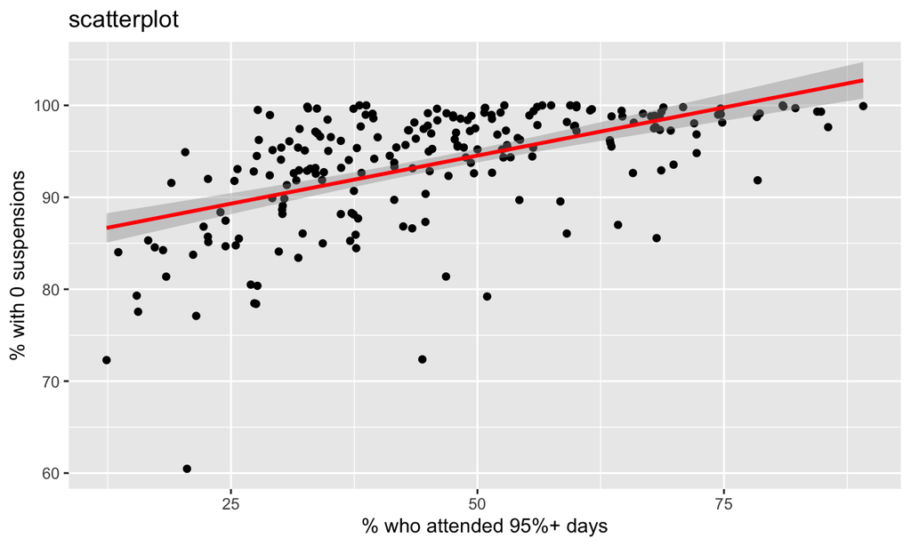

```r
# Scatterplot + regression line
ggplot(df, aes(x = att_95_pct, y = oss_0_pct)) +
  geom_point() +
  labs(title = "scatterplot",
       x = "% who attended 95%+ days",
       y = "% with 0 suspensions") +
  geom_smooth(method = lm, color = "red") # regression line
```

```r
# gray shaded area: confidence interval (the margin of uncertainty)
```

> **TODO (Regression practice).**
> - Run a regression with `att_95_numer` (Y) ~ `oss_0_numer` (X).
> - Then draw a scatterplot with a regression line using ggplot2.

# 7 Residuals (what & how to plot)

Residuals = actual − predicted.

```r
df$Residuals <- residuals(m1)
```

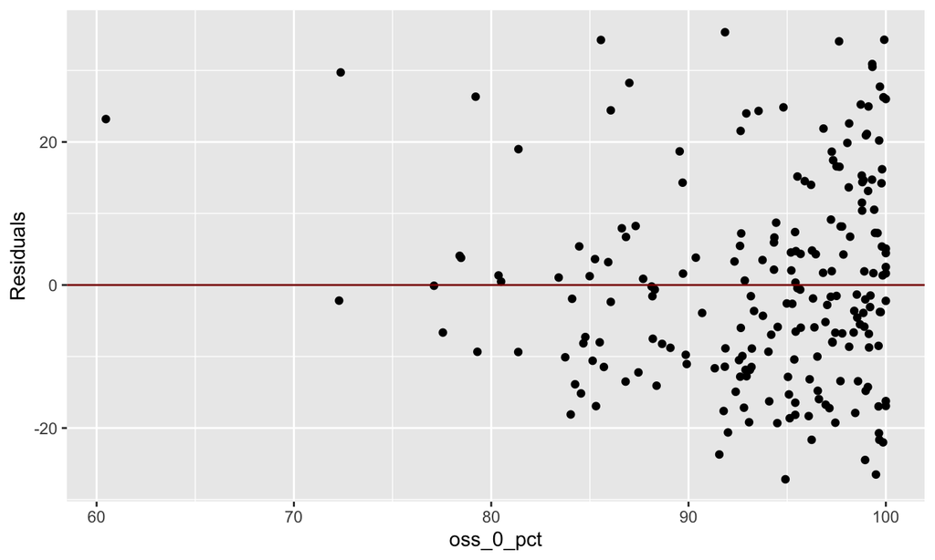

```r
# Residual plot (x vs residuals) — should be centered around 0 with no pattern
ggplot(df, aes(x = oss_0_pct, y = Residuals)) +
  geom_point() +
  geom_hline(yintercept = 0, color = "darkred")
```

# 8 Quick Practice

**P1)** Make a smaller data set for ONE school year only (e.g., 2018–2019). *Hint:* use `dplyr::filter`.

**P2)** Using this smaller dataset, run a regression `att_95_numer ~ oss_0_numer` and draw a scatterplot with a regression line using ggplot2.

# 9 Wrap-up

**Key takeaways**

- A clean start helps: `rm(list = ls())`, load packages, `setwd()`, import.
- Subset the exact columns you need (base or tidyverse).
- Check `r` for strength/direction; then fit `lm()` for slope/intercept.
- Residuals = errors → look for “no pattern” around 0.